# Casting multiple shadows: high-dimensional interactive data visualisation with tours and embeddings

Stuart Lee

Di Cook

2020-07-09

There has been a rapid uptake in the use of non-linear dimensionality reduction (NLDR) methods such as t-distributed stochastic neighbour embedding (t-SNE) in the natural sciences as part of cluster orientation and dimension reduction workflows. The appropriate use of these methods is made difficult by their complex parameterisations and the multitude of decisions required to balance the preservation of local and global structure in the resulting visualisation. We present a visual analytics framework for the pragmatic usage of NLDR methods by combining them with a technique called the tour. A tour is a sequence of interpolated linear projections of multivariate data onto a lower dimensional space. The sequence is displayed as a dynamic visualisation, allowing a user to see the shadows the high-dimensional data casts in a lower dimensional view. By linking the tour to a view obtained from an NLDR method, we can preserve global structure and through user interactions like spatial linked brushing observe where the NLDR view may be misleading. We display several case studies from single cell transciptomics and image processing, that shows our approach is useful for cluster orientation tasks. The implementation of our framework is available as an R package called `liminal` available at https://github.com/sa-lee/liminal.

## Introduction

High dimensional data is increasingly prevalent in the natural sciences and beyond but presents a challenge to the analyst in terms of both data cleaning / pre-processing and visualisation. Methods to embed data from a high-dimensional space into a low-dimensional one now form a core step of the data analysis workflow where they are used to ascertain hidden structure and de-noise data for downstream analysis (thereby nullifying the ‘curse of dimensionality’).

Choosing an appropriate embedding presents a challenge to the analyst. How does an analyst know whether the embedding has captured the underlying topology and geometry of the high dimensional space? The answer depends on the analyst’s workflow. Brehmer et al. (2014) characterised two main workflow steps that an analyst performs when using embedding techniques: dimension reduction and cluster orientation. The first relates to dimension reduction achieved by using an embedding method, here an analyst wants to characterise and map meaning onto the embedded form, for example identifying batch effects from a high throughput sequencing experiment, or identifying a gradient or trajectory along the embedded form (Nguyen and Holmes 2019). The second relates to using embeddings as part of a clustering workflow. Here analysts are interested in identifying and naming clusters and verifying them by either applying known labels or colouring by variables that are a-priori known to distinguish clusters. Both of these workflow steps rely on the embedding being representative the original high dimensional dataset, and becomes much more difficult when there is no underlying ground truth.

As part of a visualization workflow, it’s important to consider the perception and interpretation of embedding methods as well. Sedlmair, Munzner, and Tory (2013) showed that 2D scatter plots were mostly sufficient for detecting class separation, however they also noted that often multiple embeddings were required. For the task of cluster identification, Lewis, Van der Maaten, and Sa (2012) showed experimentally that novice users of non-linear embedding techniques were more likely to consider clusters of points on a 2d scatter plot to be the result of a spurious embedding compared to advanced users who were aware of the inner workings of the embedding algorithm.

A complementary approach for visualizing structure in high dimensional data is the tour. A tour is a sequence of projections of a high dimensional dataset onto a low-dimensional basis matrix, and is represented as a animated visualization.Given the dynamic nature of the tour, user interaction is important for controlling and exploring the visualisation: the tour has been used previously by Wickham, Cook, and Hofmann (2015) and Li, Zhao, and Scheidegger (2020) as a tool for exploring statistical model fits and by Buja, Cook, and Swayne (1996) for exploring the space of factorial experimental designs.

While there has been much work on the algorithmic details of the aforementioned embedding methods, there has been relatively few tools designed to assist users to interact with these techniques and assist them in making comparisons between embeddings and performing the aforementioned cluster orientation tasks. Several interactive interfaces have been proposed for evaluating or using embedding techniques: the Sleepwalk interface provides a click and highlight visualisation for colouring points in an embedding according to an estimated pairwise distance in the original high-dimensional space (Ovchinnikova and Anders 2020). The idea behind this is that non-linear embedding methods should preserve locality and that points that are ‘close’ to each other on the embedded view should be close according to the estimated pairwise distance. Similarly, the TensorFlow embedding projector is a web interface to running some non-liner embedding methods live in the browser and provides interactions to colour points, and select nearest neighbours (Smilkov et al. 2016). Finally, the work by Pezzotti et al. (2017) provides a user guided and modified form of the t-SNE algorithm, that allows users to modified optimisation parameters in real-time.

There is no one-size fits all: finding an appropriate embedding for a given dataset is a difficult and a somewhat poorly defined problem. For non-linear methods, there are a lot of parameters to explore that can have an effect on the resulting visualisation and interpretation. Interfaces for evaluating embeddings require interaction but should also be able to be incorporated into an analysts workflow. We propose a more pragmatic workflow inspired by incorporating interactive graphics and tours with embeddings that allows users to see a global overview of their high dimensional data and assists them with cluster orientation tasks. This workflow is incorporated into an R package called `liminal` (Available: https://github.com/sa-lee/liminal).

## Dimensionality Reduction Background

In the following section, we provide a brief overview of the goals of DR methods with respect to the data analyst, in addition to their high level the mathematical details. Here we restrict our attention to two recent methods that are commonly used in the literature: t-distributed stochastic neighbour embedding (t-SNE) and uniform manifold alignment and projection (UMAP); however we do mention several other techniques.

To begin we suppose the data is in the form rectangular matrix of real numbers, $X = [\mathbf{x_1}, \dots, \mathbf{x_n}]$, where $n$ is the number of observations in $p$ dimensions. The purpose of any DR algorithm is to find a low-dimensional representation of the data, $Y = [\mathbf{y_1}, \dots, \mathbf{y_n}]$, such that $Y$ is an $n \times d$ matrix where $d \ll p$. The hope of the analyst is that the DR procedure to produces $Y$ will remove noise in the original dataset while retaining any latent structure.

DR methods can be classified into two broad classes: linear and non-linear methods. Linear methods perform a linear transformation of the data, that is, $Y$ is a linear transformation of $X$; one example is principal components analysis (PCA) which performs an eigendecomposition of the estimated sample covariance matrix. The eigenvalues are sorted in decreasing order and represent the variance explained by each component (eigenvector). A common approach to deciding on the number of principal components to retain is to plot the proportion of variance explained by each component and choose a cut-off.

For non-linear methods $Y$ is generated via a pre-processed form of the input $X$ such as the $k$-nearest neighbours graph or via a kernel transformation. Multidimensional scaling (MDS) is a class of DR methods that aims to construct an embedding $Y$ such that the pairwise distances (inner products) in $Y$ approximate the pairwise distances (inner products) in $X$ (Torgerson 1952; Kruskal 1964a). There are many variants of MDS, such as non-metric scaling which amounts to replacing distances with ranks instead (Kruskal 1964b). A related technique is Isomap which uses a $k$-nearest neighbour graph to estimate the pairwise geodesic distance of points in $X$ then uses classical MDS to construct $Y$ (Silva and Tenenbaum 2003). Other approaches are based on diffusion processes such asdiffusion maps (Coifman et al. 2005). A recent example of this approach is the PHATE algorithm (Moon et al. 2019). Here an affinity matrix is estimated via the pairwise distance matrix and k-nearest neighbours graph of $X$. The algorithm de-noises estimated distances in high-dimensional space via transforming the affinity matrix into a Markov transition probability matrix and diffusing this matrix over a fixed number of time steps. Then the diffused probabilities are transformed once more to construct a distance matrix, and classical MDS is used to generate $Y$. A general difficulty with using non-linear DR methods for exploratory data analysis is selecting and tuning appropriate parameters. To see the extent of these choices we now examine the underpinnings of t-SNE and UMAP.

The t-SNE algorithm estimates the pairwise similarity of (Euclidean) distances of points in a high dimensional space using a Gaussian distribution and then estimates a configuration in the low dimensional embedding space by modelling similarities using a t-distribution with 1 degree of freedom. There are several subtleties to the to use of the algorithm that are revealed by stepping through its machinery.

To begin, t-SNE transforms pairwise distances between $\mathbf{x_i}$ and $\mathbf{x_j}$ to similarities using a Gaussian kernel:

$$p_{i|j} = \frac{\exp(-\lVert \mathbf{x_i - x_j} \rVert ^ 2 /
2\sigma_i^2)}{\sum_{k \ne i}\exp(-\lVert \mathbf{x_j - x_k} \rVert ^ 2 /
2\sigma_i^2)}$$

The conditional probabilities are then normalised and symmetrised to form a joint probability distribution via averaging:

$$p_{ij} = \frac{p_{i|j} + p_{j|i}}{2n}$$

The variance parameter of the Gaussian kernel is controlled by the analyst using a fixed value of perplexity for all observations:

$$\text{perplexity}_i = \exp(-\log(2) \sum_{i \ne j}p_{j|i}\log_2(p_{j|i}))$$
As the perplexity increases, $\sigma^2_{i}$ increases, until its bounded above by the number of observations , $n-1$, in the data, corresponding to $\sigma^2_{i} \rightarrow \infty$. This essentially turns $t-SNE$ into a nearest neighbours algorithm, $p_{i|j}$ will be close to zero for all observations that are not in the $\mathcal{O}(\text{perplexity}_i)$ neighbourhood graph of the $i$th observation (Van Der Maaten 2014).

Next, the target low-dimensional space, $Y$, pairwise distances between $\mathbf{y_i}$ and $\mathbf{y_j}$ are modelled as a symmetric probability distribution using a Cauchy kernel:

$$q_{ij} = \frac{w_{ij}}{Z} \\ \text{where } w_{ij} = \frac{1}{ 1 + \lVert
\mathbf{y_i - y_j} \rVert ^ 2} \text{ and } Z = \sum_{k \ne l} w_{kl}.$$

The resulting embedding $Y$ is the one that minimizes the Kullback-Leibler divergence between the probability distributions formed via similarities of observations in $X$, $\mathcal{P}$ and similarities of observations in $Y$, $\mathcal{Q}$:

$$\mathcal{L(\mathcal{P}, \mathcal{Q})} = \sum_{i \ne j} p_{ij} \log
\frac{p_{ij}}{q_{ij}}$$

$$\mathcal{L(\mathcal{P}, \mathcal{Q})} = -\sum_{i \ne j} p_{ij}\log w_{ij} +
\log\sum_{i \ne j} w_{ij}$$

So when the the loss function is minimised this corresponds to large attractive forces, that is, the pairwise distances in $Y$ are small when there are non-zero $p_{ij}$, i.e. $x_i$ and $x_j$ are close together. The repulsive force should also be small when the loss function is minimised, that is, when pairwise distances in $Y$ are large regardless of the magnitude of the corresponding distances in $X$.

Taken together, these details reveal the sheer number of decisions that an analyst must make. How does one choose the perplexity? How should the parameters that control the optimisation of the loss function (done with stochastic gradient descent), like the number of iterations, or early exaggeration ( a multiplier of the attractive force at the beginning of the optimisation), or the learning rate be selected? It is a known problem that t-SNE can have trouble recovering topology and that configurations can be highly dependent on how the algorithm is initialised and parameterized (Wattenberg, Viégas, and Johnson 2016; Kobak and Berens 2019; Melville, n.d.). If the goal is cluster orientation a recent theoretical contribution by Linderman and Steinerberger (2019) proved that t-SNE can recover spherical and well separated cluster shapes, and proposed new approaches for tuning the optimisation parameters. However, the cluster sizes and their relative orientation from a $t-SNE$ view can be misleading perceptually, due to the algorithms emphasis on locality.

Another recent method UMAP has seen a large rise in popularity (at least in single cell transcriptomics) (McInnes, Healy, and Melville 2018). It is a method that is related to LargeVis (Tang et al. 2016), and like t-SNE acts on the k-nearest neighbour graph. Its main differences are that it uses a different cost function (cross entropy) which is optimized using stochastic gradient descent and defines a different kernel for similarities in the low dimensional space. Due to it’s computational speed it’s possible to generate UMAP embeddings in more than three dimensions. It appears to suffer from the same perceptual issues as t-SNE, however it supposedly preserves global structure better than t-SNE (Coenen and Pearce 2019).

## Visual Design

We propose using tours as part of an analyst’s workflow when using embedding methods like t-SNE. We have made extensive use of ensemble graphics, that is aligning related plots alongside each other to provide context (Unwin and Valero-Mora 2018). As we will see in the case studies, this allows analysts to quickly compare views from embedding methods and allows them to see how the embedding method alters the global structure of their data. Using ensembles allows the use of interaction techniques, that allow analysts to perform cluster orientation tasks via linking multiple views. This approach allows our interface, to achieve the three principles for interactive high-dimensional data visualisation outlined by Buja, Cook, and Swayne (1996): finding gestalt, posing queries, and making comparisons.

### Finding Gestalt: focus and context

To investigate latent structure and the shape of a high dimensional dataset, a tour can be run without the use of an external embedding. It is often useful to first run principal components on the input as an initial dimension reduction step, and then tour a subset of those components instead, i.e. by selecting them from a scree plot. The default tour layout is a scatter plot with an axis layout displaying the magnitude and direction of each basis vector. Since the tour is dynamic, it is often useful to be able to pause and highlight a particular view. In our interface, brushing will pause the tour path, allowing users to identify ‘interesting’ projections. The domain of the axis scales from running a tour is called the half range, and is computed by rescaling the input data onto hyper-dimensional unit cube. We bind the half range to a mouse wheel event, allowing a user to pan and zoom on the tour view dynamically. This is useful for peeling back dense clumps of points to reveal structure.

### Posing Queries: multiple views, many contexts

We have combined the tour view in a side by side layout with a scatter plot view that represents the output of an embedding algorithm. These views are linked; analysts can brush regions or highlight collections of points in either view. Linked highlighting can be performed when points have been previously labelled according to some discrete structure, i.e. cluster labels are available. This is achieved via the analyst clicking on groups in the legend, which causes unselected groupings to have their points become less opaque. Consequently, simple linked highlighting can alleviate a known downfall of methods such as UMAP or t-SNE: that is distances between clusters are misleading. By highlighting corresponding clusters in the tour view, the analyst can see the relationship between clusters, and therefore obtain a more accurate representation of the topology of their data.

Simple linked brushing is achieved via mouse-click and drag movements. By default, when brushing occurs in the tour view, the current projection is paused and corresponding points in the embedding view are highlighted. Likewise, when brushing occurs in the embedding view, corresponding points in the tour view are highlighted. In this case, an analyst can use brushing for manually identifying clusters and verifying cluster locations and shapes: brushing in the embedding view gives analysts a sense of the shape and proximity of cluster in high-dimensional space.

### Making comparisons: revising embeddings

Look up nearest neighbours graph from points that lie in a brushing region.

Highlight the corresponding neighbours using colour or transparency in the linked view.

- The $k$ nearest neighbours graph can be pre-computed quickly, for either $X$, $Y$ or both.
- Instead of using the neighbour indices, we could use the neighbour distances instead.
- Composition of multiple brushes could be used to show where there are matches/mismatches between nearest neighbour graphs.

Using a linked neighbourhood brush, we can visually investigate the nearest neighbour relationships in the high-dimensional space via brushing in the embedding view. The user can select the number of nearest neighbours directly, and modify the distance metric used for determining the neighbours. This allows users to interrogate the stability of clusters generated in the embedding view. Multiple brushes can be used to pose queries in either the tour view or the embedding view; interface controls allow these brushes to combine using logical operators such as ‘and’, ‘or’, or ‘not’. The use of linked brushing goes beyond simple colour highlights, allowing analysts to get a more holistic view of the effect of an embedding algorithm.

## Software Infrastructure

We have implemented the above design as an open source R package called `liminal` (R Core Team 2019). The package allows analysts to construct concatenated visualisations, via the Vega-Lite grammar of interactive graphics (using `vegawidget` package) and provides an interface for constructing brushes and manipulating tour paths using the `shiny` and `tourr` packages. `liminal` also provides a stand-alone interface to the tour, in addition to the linked scatterplot interfaces discussed above. Below we display the `liminal` API, and our approach to generating tour paths and user interactions.

### Tours explore the subspace of $d$-dimensional projections

Here we provide an overview of the mathematical aspects of the tour for readers who are unfamiliar with the technique before discussing the computational aspects of how `liminal` interfaces with them. The tour is emphatically not a dimension reduction technique but rather a visualisation technique that is grounded in mathematical theory, that is able to ascertain the shape and global structure of a dataset via inspection of the subspace generated by the set of low-dimensional projections. In fact, in some of the case studies below, we first sphere our data via principal components to reduce dimensionality of our input.

Like, when using DR techniques, the tour assumes we have a real data matrix $X$ consisting of $n$ observations in $p$ dimensions. First, the tour generates a sequence of $p \times d$ orthonormal projection matrices (bases) $A_{t \in \mathbb{N}}$, where $d$ is typically $1$ or $2$. For each pair of orthonormal bases $A_{t}$ and $A_{t+1}$ that are generated, the geodesic path between them is interpolated to form intermediate frames, and giving the sense of continuous movement from one basis to another. The tour is then the continuous visualisation of the projections $Y_{t} = XA_{t}$, that is the projection of $X$ onto $A_{t}$ as the tour path is interpolated between successive bases. A *grand tour* corresponds to choosing new orthonormal bases at random; allowing a user to ascertain structure via exploring the subspace of $d$-dimensional projections. Instead of picking projections at random, a *guided tour* can be used to generate a sequence ‘interesting’ projections as quantified by an index function. While `liminal` is able to visualise guided tours, our focus in the case studies uses the grand tour to see global structure in the data.

### Tours as a streaming data problem

The process of generating successive bases and interpolating between them to  
construct intermediary frames, means the tour is a dynamic visualisation technique. Generally, the user would set $d=2$ the tour is visualised as a animated scatterplot. This process of constructing bases and intermediate frames and visualising the resulting projection is akin to making a “flipbook” animation. Like with a flipbook, an interface to the tour requires the ability to interact and modify it in real time. The user interface generated in `liminal` allows a user to play, pause, and reset the tour animation, panning and zooming to modify the scales of the plot to provide context and click events to highlight groups of points if a labelling variable has been placed on the legend.

These interactions are enabled by treating the basis generation as a reactive stream. Instead of realising the entire sequence, which limits the animation to have a discrete number of frames, new bases and their intermediate frames are generated dynamically via pushing the current projection to the visualisation interface. The interface listens to events like pressing a button or mouse-dragging and reacts by pausing the stream. This process allows the user to manipulate the tour in real time rather than having to fix the number of bases ahead of time. Additionally, once the user has identified an interesting projection or is done with the tour, the interface will return the current basis for use downstream.

### Linking and highlighting views via interactions

The embedding and tour views are linked together via rectangular brushes; when a brush is active, points will be highlighted in the adjacent view. Because the tour is dynamic, brush events that become active will pause the animation, so that a user can interrogate the current view. By default, brushing on the embedding view will produce a one-to-one linking with the tour view (the special case of $k=1$ nearest neighbors brush). It is possible to shift to one-to-many linking by increasing $k$ via the ‘controls’ panel of the interface. If desired, the distance metric used to estimate nearest neighbours can by chosen by the user. The user may provide a reference data set for computing nearest neighbours (for example a distance matrix, or the complete data matrix) independently of the tour or embedding views. The estimation of neighbours is done with the `FNN` package for datasets with less than 4096 observations and `RcppAnnoy` for larger datasets or if a user selects a non-euclidean distance metric (Beygelzimer et al. 2019; Eddelbuettel 2020). Once the user is finished with the interface, the brush regions are returned for downstream analysis.

## Case Studies

### Case Study 1: Exploring tree structured data with tours and t-SNE

In this case study we explore some simulated noisy tree structured data (figure 1), our interest here is how t-SNE visualisations break topology of the data, and then seeing if we can resolve this by tweaking the default parameters with reference to the global view of the data set.

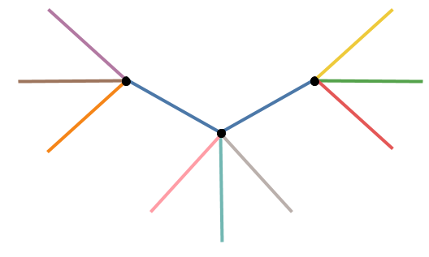

Figure 1: Example high-dimensional tree shaped data, $n = 3000$ and $p = 100$. The data lies 2-d tree like structure consisting of ten branches. This data is available in the `phateR` package and is simulated via diffusion-limited aggregation (a random walk along the branches of the tree) with Gaussian noise added. (Moon et al. 2019).

First, we apply principal components and restrict the results down to the first twelve principal components (which makes up approximately 70% of the variance explained in the data) to use with the grand tour.

Moreover, we run t-SNE using the default arguments on the complete data (this keeps the first 50 PCs, sets the perplexity to equal 30 and performs random initialisation) using the `Rtsne` package (Krijthe 2015). We then create a linked tour with t-SNE layout with `liminal` as shown in the following video :

<embedded video 1>

From the video, we see that the t-SNE view has been unable to recapitulate the topology of the tree - the backbone (blue) branch has been split into three fragments. We can see this immediately via the linked highlighting over both plots. If we click on the legend for the zero branch, the blue coloured points on each view are highlighted and the remaining points are made transparent. From, here it becomes apparent from the tour view that the blue branch forms the backbone of the tree and is connected to all other branches. We can also again see that cluster sizes formed via t-SNE can be misleading; from the tour view there is a lot of noise along the branches, while this does not appear to be the case for the t-SNE result.

From the first view, we modify the inputs to the t-SNE view, to try and produce a better trade-off between local structure and retain the topology of the data. We keep every parameter the same except that we initialise $Y$ with the first two PCs (scaled to have standard deviation 1e-4) instead of the default random initialisation and increase the perplexity from 30 to 100. We then combine these results with our tour view as displayed in the video:

<embedded video 2>

The video shows that this selection of parameters results in the the tips of the branches (the three black dots in figure 1) being split into three clusters representing the final branches of the tree. However, there are perceptual issues following the placement of the three groupings on the t-SNE view that become apparent via simple linked brushing. If we brush the tips of the yellow and brown branches (which appear to be close to each other on the t-SNE view), we immediately see the placement is distorted in the t-SNE view, and in the tour view these tips are at opposite ends of the tree. Although, this is a known issue of the t-SNE algorithm, we can easily identify it via simple interactivity.

### Case Study 2: Clustering single cell RNA-seq data

A common analysis task in single cell studies is performing clustering to identify groupings of cells with similar expression profiles. Analysts in this area generally use non linear DR methods for verification and identification of clusters and developmental trajectories (i.e., case study 1). For clustering, workflows the primary task is verify the existence of clusters and then begin to identify the clusters as cell types using the expression of “known” marker genes. Here a ‘faithful’ a embedding should ideally preserve the topology of the data; cells that correspond to a cell type should lie in the same neighbourhood in high-dimensional space. In this case study we use our spatial and linked brushing approaches to look at neighbourhood preservation (which can be seen via the tour) and to look at the affect of applying different feature selection techniques and distance metrics.

First, we downloaded the raw mouse retinal single cell RNA-seq data from Macosko et al. (2015) using the `scRNAseq` Bioconductor package (Risso and Cole 2019). We have followed a standard workflow for pre-processing and normalizing this data (described by Amezquita et al. (2020)): we performed QC using the the `scater` by removing cells with high proportion of mitochondrial gene expression and low numbers of genes detected, we log-transformed and normalised the expression values and finally selected highly variable genes (HVGs) using `scran` (McCarthy et al. 2017; Lun, McCarthy, and Marioni 2016). The top ten percent of HVGs were used to subset the normalised expression matrix and compute PCA using the first 25 components. Using the PCs we built a shared nearest neighbours graph (with $k = 10$) and used Louvain clustering to generate clusters. To check and verify the clustering we construct a liminal view. Because most off the variability in expression is explained by the first 5 PCs, we tour those. The t-SNE view is computed from all PCs

- compare to just using the HVGs themselves with the tour
- neighbourhood based brushing to check how diffuse or distorted clusters are
- different distance metrics?

### Case Study 3: How do people draw animals?

In the final case study, we explore a subset of the Google QuickDraw dataset (“Quick, Draw! The Data,” n.d.). The data are sketches drawn by people of common concepts like ‘airplane’ or ‘shoe’, and corresponding metadata about the humans who created the sketches, such as country, the word category, whether the sketch was recognised by Google’s neural network, and the number of strokes taken. We downloaded the metadata and normalised 28 by 28 pixel bitmaps via the `quickdraw` package in R; unravelling the bitmaps unravelled the bitmaps into a 784 dimension image vector. We sampled 500 images from each of the following categories: “broccoli”, “flying saucer”, “ice cream”, “octopus”, “pineapple”, and “whale”.

## Discussion

- limitations: large $n$, latency issues
- future work: regularisation tour, slicing and sectioning

## References

Amezquita, Robert A, Aaron T L Lun, Etienne Becht, Vince J Carey, Lindsay N Carpp, Ludwig Geistlinger, Federico Marini, et al. 2020. “Orchestrating Single-Cell Analysis with Bioconductor.” *Nat. Methods* 17 (2):137–45. https://doi.org/10.1038/s41592-019-0654-x.

Beygelzimer, Alina, Sham Kakadet, John Langford, Sunil Arya, David Mount, and Shengqiao Li. 2019. *FNN: Fast Nearest Neighbor Search Algorithms and Applications*. https://CRAN.R-project.org/package=FNN.

Brehmer, Matthew, Michael Sedlmair, Stephen Ingram, and Tamara Munzner. 2014. “Visualizing Dimensionally-Reduced Data: Interviews with Analysts and a Characterization of Task Sequences.” In *Proceedings of the Fifth Workshop on Beyond Time and Errors: Novel Evaluation Methods for Visualization*, 1–8. dl.acm.org. https://dl.acm.org/doi/abs/10.1145/2669557.2669559.

Buja, Andreas, Dianne Cook, and Deborah F Swayne. 1996. “Interactive High-Dimensional Data Visualization.” *J. Comput. Graph. Stat.* 5 (1). [American Statistical Association, Taylor & Francis, Ltd., Institute of Mathematical Statistics, Interface Foundation of America]:78–99. https://doi.org/10.2307/1390754.

Coenen, Andy, and Adam Pearce. 2019. “Understanding UMAP.” https://pair-code.github.io/understanding-umap/. https://pair-code.github.io/understanding-umap/.

Coifman, R R, S Lafon, A B Lee, M Maggioni, B Nadler, F Warner, and S W Zucker. 2005. “Geometric Diffusions as a Tool for Harmonic Analysis and Structure Definition of Data: Diffusion Maps.” *Proc. Natl. Acad. Sci. U. S. A.* 102 (21):7426–31. https://doi.org/10.1073/pnas.0500334102.

Eddelbuettel, Dirk. 2020. *RcppAnnoy: ’Rcpp’ Bindings for ’Annoy’, a Library for Approximate Nearest Neighbors*. https://CRAN.R-project.org/package=RcppAnnoy.

Kobak, Dmitry, and Philipp Berens. 2019. “The Art of Using t-SNE for Single-Cell Transcriptomics.” *Nat. Commun.* 10 (1):5416. https://doi.org/10.1038/s41467-019-13056-x.

Krijthe, Jesse H. 2015. *Rtsne: T-Distributed Stochastic Neighbor Embedding Using Barnes-Hut Implementation*. https://github.com/jkrijthe/Rtsne.

Kruskal, J B. 1964a. “Multidimensional Scaling by Optimizing Goodness of Fit to a Nonmetric Hypothesis.” *Psychometrika* 29 (1). Springer-Verlag:1–27. https://doi.org/10.1007/BF02289565.

———. 1964b. “Nonmetric Multidimensional Scaling: A Numerical Method.” *Psychometrika* 29 (2):115–29. https://doi.org/10.1007/BF02289694.

Lewis, Joshua, Laurens Van der Maaten, and Virginia de Sa. 2012. “A Behavioral Investigation of Dimensionality Reduction.” In *Proceedings of the Annual Meeting of the Cognitive Science Society*. Vol. 34. escholarship.org. https://escholarship.org/content/qt0ss3m55c/qt0ss3m55c.pdf.

Li, Mingwei, Zhenge Zhao, and Carlos Scheidegger. 2020. “Visualizing Neural Networks with the Grand Tour.” *Distill* 5 (3). https://doi.org/10.23915/distill.00025.

Linderman, George C, and Stefan Steinerberger. 2019. “Clustering with t-SNE, Provably.” *SIAM Journal on Mathematics of Data Science* 1 (2). Society for Industrial; Applied Mathematics:313–32. https://doi.org/10.1137/18M1216134.

Lun, Aaron T. L., Davis J. McCarthy, and John C. Marioni. 2016. “A Step-by-Step Workflow for Low-Level Analysis of Single-Cell Rna-Seq Data with Bioconductor.” *F1000Res.* 5:2122. https://doi.org/10.12688/f1000research.9501.2.

Macosko, Evan Z, Anindita Basu, Rahul Satija, James Nemesh, Karthik Shekhar, Melissa Goldman, Itay Tirosh, et al. 2015. “Highly Parallel Genome-Wide Expression Profiling of Individual Cells Using Nanoliter Droplets.” *Cell* 161 (5):1202–14. https://doi.org/10.1016/j.cell.2015.05.002.

McCarthy, Davis J., Kieran R. Campbell, Aaron T. L. Lun, and Quin F. Willis. 2017. “Scater: Pre-Processing, Quality Control, Normalisation and Visualisation of Single-Cell RNA-Seq Data in R.” *Bioinformatics* 33 (8):1179–86. https://doi.org/10.1093/bioinformatics/btw777.

McInnes, Leland, John Healy, and James Melville. 2018. “UMAP: Uniform Manifold Approximation and Projection for Dimension Reduction,” February. http://arxiv.org/abs/1802.03426.

Melville, James. n.d. “t-SNE Initialization Options.” https://jlmelville.github.io/smallvis/init.html. https://jlmelville.github.io/smallvis/init.html.

Moon, Kevin R, David van Dijk, Zheng Wang, Scott Gigante, Daniel B Burkhardt, William S Chen, Kristina Yim, et al. 2019. “Visualizing Structure and Transitions for Biological Data Exploration.” *bioRxiv*. https://doi.org/10.1101/120378.

Nguyen, Lan Huong, and Susan Holmes. 2019. “Ten Quick Tips for Effective Dimensionality Reduction.” *PLoS Comput. Biol.* 15 (6):e1006907. https://doi.org/10.1371/journal.pcbi.1006907.

Ovchinnikova, Svetlana, and Simon Anders. 2020. “Exploring Dimension-Reduced Embeddings with Sleepwalk.” *Genome Res.* 30 (5):749–56. https://doi.org/10.1101/gr.251447.119.

Pezzotti, Nicola, Boudewijn P F Lelieveldt, Laurens Van Der Maaten, Thomas Hollt, Elmar Eisemann, and Anna Vilanova. 2017. “Approximated and User Steerable tSNE for Progressive Visual Analytics.” *IEEE Trans. Vis. Comput. Graph.* 23 (7):1739–52. https://doi.org/10.1109/TVCG.2016.2570755.

“Quick, Draw! The Data.” n.d. https://quickdraw.withgoogle.com/data. https://quickdraw.withgoogle.com/data.

R Core Team. 2019. *R: A Language and Environment for Statistical Computing*. Vienna, Austria: R Foundation for Statistical Computing. https://www.R-project.org/.

Risso, Davide, and Michael Cole. 2019. *ScRNAseq: Collection of Public Single-Cell Rna-Seq Datasets*.

Sedlmair, Michael, Tamara Munzner, and Melanie Tory. 2013. “Empirical Guidance on Scatterplot and Dimension Reduction Technique Choices.” *IEEE Trans. Vis. Comput. Graph.* 19 (12):2634–43. https://doi.org/10.1109/TVCG.2013.153.

Silva, V D, and J B Tenenbaum. 2003. “Global Versus Local Methods in Nonlinear Dimensionality Reduction.” *Adv. Neural Inf. Process. Syst.* papers.nips.cc. http://papers.nips.cc/paper/2141-global-versus-local-methods-in-nonlinear-dimensionality-reduction.pdf.

Smilkov, Daniel, Nikhil Thorat, Charles Nicholson, Emily Reif, Fernanda B Viégas, and Martin Wattenberg. 2016. “Embedding Projector: Interactive Visualization and Interpretation of Embeddings,” November. http://arxiv.org/abs/1611.05469.

Tang, Jian, Jingzhou Liu, Ming Zhang, and Qiaozhu Mei. 2016. “Visualizing Large-Scale and High-Dimensional Data,” February. http://arxiv.org/abs/1602.00370.

Torgerson, Warren S. 1952. “Multidimensional Scaling: I. Theory and Method.” *Psychometrika* 17 (4). Springer-Verlag:401–19. https://doi.org/10.1007/BF02288916.

Unwin, Antony, and Pedro Valero-Mora. 2018. “Ensemble Graphics.” *J. Comput. Graph. Stat.* 27 (1). Taylor & Francis:157–65. https://doi.org/10.1080/10618600.2017.1383264.

Van Der Maaten, L. 2014. “Accelerating t-SNE Using Tree-Based Algorithms.” *J. Mach. Learn. Res.* jmlr.org. http://www.jmlr.org/papers/volume15/vandermaaten14a/vandermaaten14a.pdf.

Wattenberg, Martin, Fernanda Viégas, and Ian Johnson. 2016. “How to Use t-SNE Effectively.” *Distill* 1 (10). https://doi.org/10.23915/distill.00002.

Wickham, Hadley, Dianne Cook, and Heike Hofmann. 2015. “Visualizing Statistical Models: Removing the Blindfold.” *Statistical Analysis and Data Mining: The ASA Data Science Journal* 8 (4). Wiley Subscription Services, Inc., A Wiley Company:203–25. https://doi.org/10.1002/sam.11271.